# ExploreAndSummarize

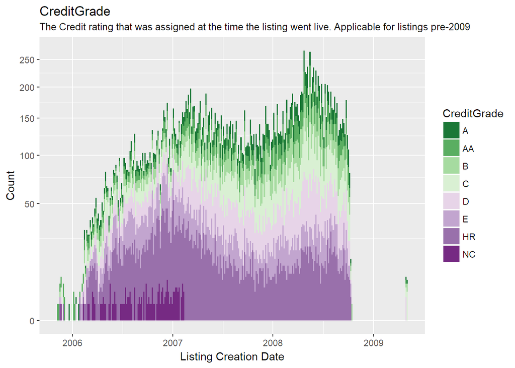

```r
RawData%>%
  filter(!CreditGrade=="")%>%
  ggplot(aes(x=ListingCreationDate,fill=CreditGrade))+
  geom_histogram(bins=300)+
  coord_trans(y="sqrt")+
  scale_fill_brewer(palette = 3,type = "div",direction = -1)+
  labs(title="CreditGrade ",
       subtitle="The Credit rating that was assigned at the time the listing went live. Applicable for listings pre-2009",
       x="Listing Creation Date",
       y="Count",
       fill="CreditGrade")
```

Monthly Loan Payment vs time

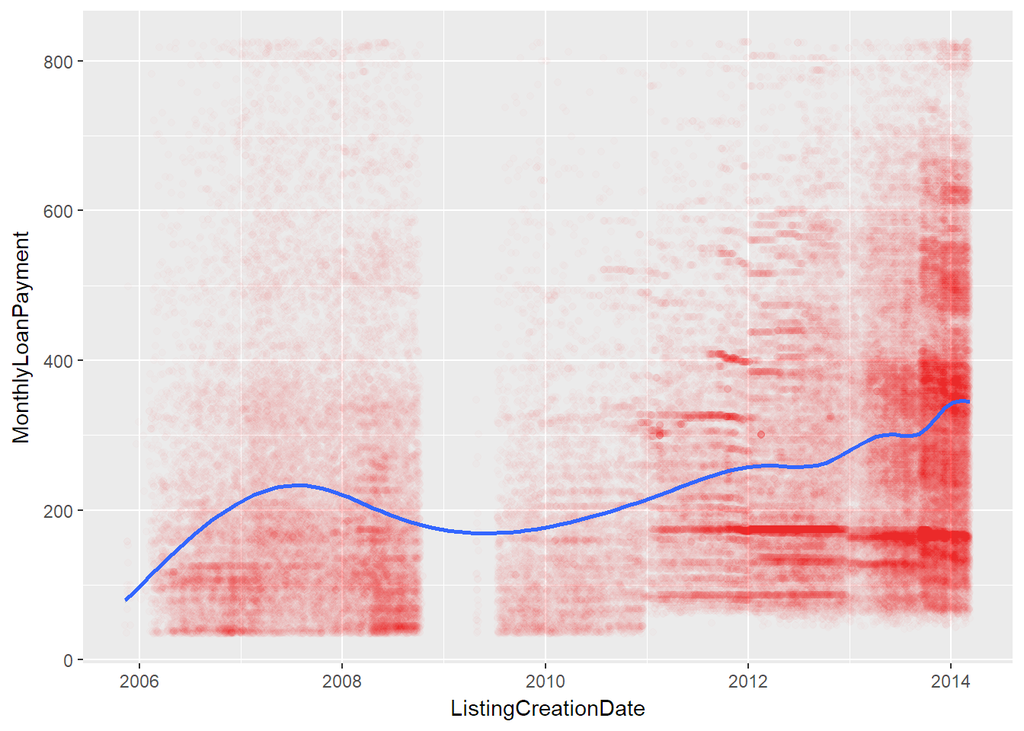

```r
RawData %>%
  filter(MonthlyLoanPayment>quantile(MonthlyLoanPayment,0.02))%>%
  filter(MonthlyLoanPayment<quantile(MonthlyLoanPayment,0.98))%>%
  ggplot(aes(x=ListingCreationDate,y=MonthlyLoanPayment))+
  geom_jitter(alpha=0.01,color="red")+
  geom_smooth(method="auto",level=0.5,span=0.3,n=100)
```

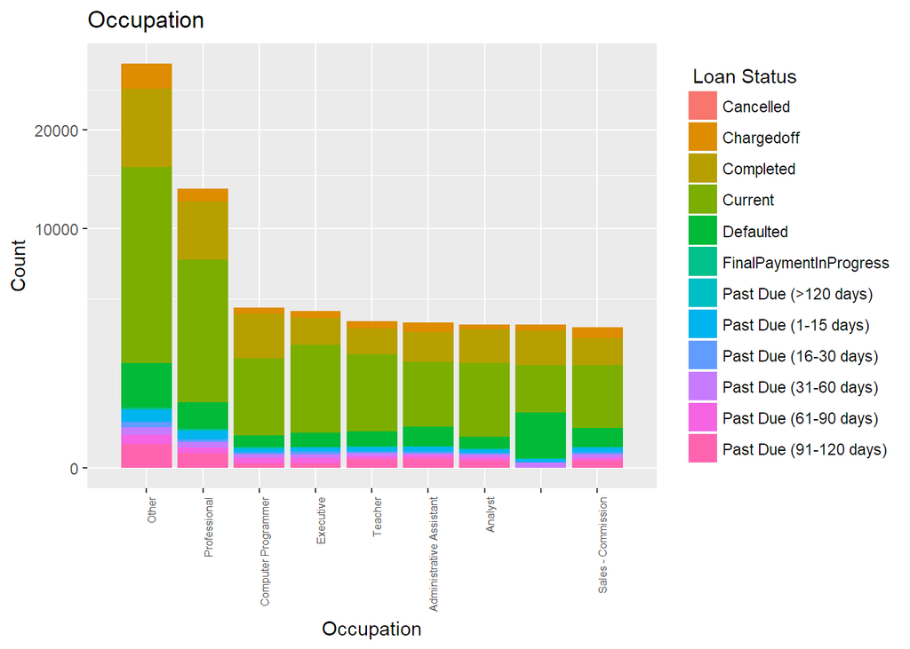

```r
topOcc=levels(reorder(RawData$Occupation, -table(RawData$Occupation)[RawData$Occupation]))[0:9]
RawData%>%
  filter(Occupation %in% topOcc)%>%
  ggplot(aes(x=reorder(Occupation, -table(Occupation)[Occupation]),fill=LoanStatus))+
  geom_bar()+
  coord_trans(y="sqrt")+
  theme(axis.text.x = element_text(size=6, angle=90,hjust = 1))+
  #scale_fill_brewer(palette = "Spectral")+
  labs(title="Occupation ", x="Occupation", y="Count",fill=" Loan Status")
```

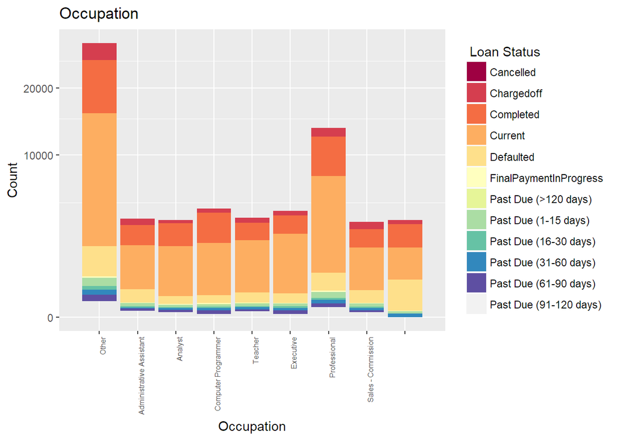

```r
topOcc=levels(reorder(RawData$Occupation, -table(RawData$Occupation)[RawData$Occupation]))[0:9]
RawData %>%
  filter(Occupation %in% topOcc)%>%
  #filter(!Occupation=="")%>%
  #filter(!LoanStatus=="")%>%
  count(Occupation,LoanStatus)%>%
  ggplot(aes(x=reorder(Occupation, -table(Occupation)[Occupation]),fill=LoanStatus,y=n))+
    geom_bar(stat = "identity")+
    coord_trans(y="sqrt")+
    theme(axis.text.x = element_text(size=6, angle=90,hjust = 1))+
    scale_fill_brewer(palette = "Spectral")+
    labs(title="Occupation ", x="Occupation", y="Count",fill=" Loan Status")
```

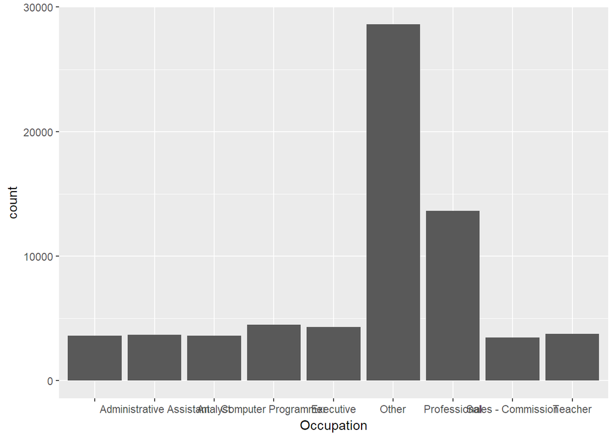

```r
topOcc=levels(reorder(RawData$Occupation, -table(RawData$Occupation)[RawData$Occupation]))[0:9]
RawData%>%
  filter(Occupation %in% topOcc)%>%
  ggplot(aes(x=Occupation))+geom_bar()
```

```r
#levels(RawData$Occupation)
levels(reorder(RawData$Occupation, -table(RawData$Occupation)[RawData$Occupation]))[0:10]
```

```
##  [1] "Other"                    "Professional"
##  [3] "Computer Programmer"      "Executive"
##  [5] "Teacher"                  "Administrative Assistant"
##  [7] "Analyst"                  ""
##  [9] "Sales - Commission"       "Accountant/CPA"
```

```r
#levels(t)
```

```r
BIT=table(RawData$Occupation)[RawData$Occupation]
```

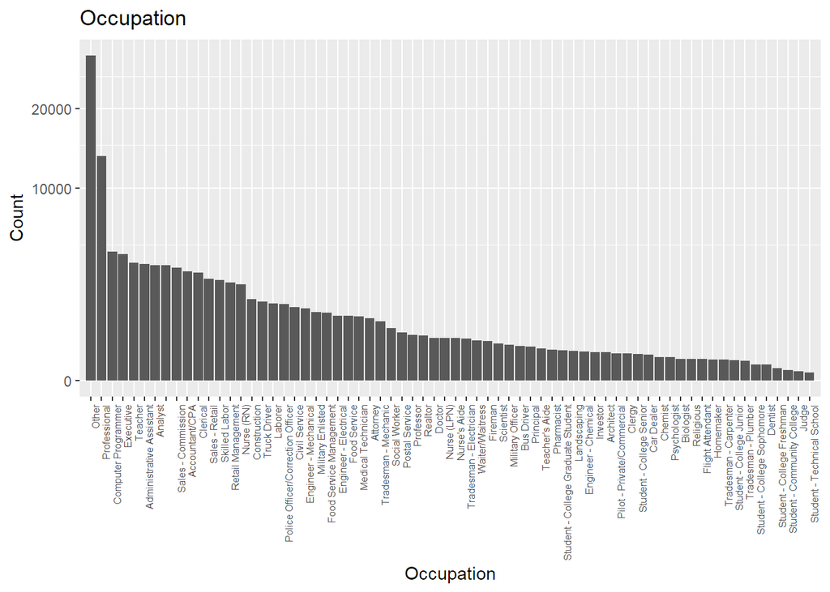

```r
RawData%>%
  ggplot(aes(x=reorder(Occupation, -table(Occupation)[Occupation])))+
  geom_bar()+
  coord_trans(y="sqrt")+
  #ylim(500,100000)+
  theme(axis.text.x = element_text(size=6, angle=90,hjust = 1))+
  labs(title="Occupation ", x="Occupation", y="Count")
```

[output not shown]

# Univariate Analysis

> **Tip**: Now that you’ve completed your univariate explorations, it’s time to reflect on and summarize what you’ve found. Use the questions below to help you gather your observations and add your own if you have other thoughts!

### What is the structure of your dataset?

### What is/are the main feature(s) of interest in your dataset?

### What other features in the dataset do you think will help support your

investigation into your feature(s) of interest?

### Did you create any new variables from existing variables in the dataset?

### Of the features you investigated, were there any unusual distributions?

Did you perform any operations on the data to tidy, adjust, or change the form  
of the data? If so, why did you do this?

# Bivariate Plots Section

> **Tip**: Based on what you saw in the univariate plots, what relationships between variables might be interesting to look at in this section? Don’t limit yourself to relationships between a main output feature and one of the supporting variables. Try to look at relationships between supporting variables as well.

# Bivariate Analysis

> **Tip**: As before, summarize what you found in your bivariate explorations here. Use the questions below to guide your discussion.

### Talk about some of the relationships you observed in this part of the

investigation. How did the feature(s) of interest vary with other features in  
the dataset?

### Did you observe any interesting relationships between the other features

(not the main feature(s) of interest)?

### What was the strongest relationship you found?

# Multivariate Plots Section

> **Tip**: Now it’s time to put everything together. Based on what you found in the bivariate plots section, create a few multivariate plots to investigate more complex interactions between variables. Make sure that the plots that you create here are justified by the plots you explored in the previous section. If you plan on creating any mathematical models, this is the section where you will do that.

# Multivariate Analysis

### Talk about some of the relationships you observed in this part of the

investigation. Were there features that strengthened each other in terms of  
looking at your feature(s) of interest?

### Were there any interesting or surprising interactions between features?

### OPTIONAL: Did you create any models with your dataset? Discuss the

strengths and limitations of your model.

# Final Plots and Summary

> **Tip**: You’ve done a lot of exploration and have built up an understanding of the structure of and relationships between the variables in your dataset. Here, you will select three plots from all of your previous exploration to present here as a summary of some of your most interesting findings. Make sure that you have refined your selected plots for good titling, axis labels (with units), and good aesthetic choices (e.g. color, transparency). After each plot, make sure you justify why you chose each plot by describing what it shows.

### Plot Three

# Reflection

> **Tip**: Here’s the final step! Reflect on the exploration you performed and the insights you found. What were some of the struggles that you went through? What went well? What was surprising? Make sure you include an insight into future work that could be done with the dataset.

> **Tip**: Don’t forget to remove this, and the other **Tip** sections before saving your final work and knitting the final report!